# Visuals for Categorical Data

Muhammad Hilmi Abdul Majid

## Introduction

We have been introduced with the basics of ggplot2 in the previous topic. Now, we can begin looking at various types of graphs, plots, or visuals. The first that we will look at are visuals for distributions. Distributions show how data values are spread, which is essential for identifying patterns, trends, and potential outliers.

In this topic, we will look at visuals for distributions of categorical data including text data. Then in the next topic, we will show how to produce visuals for distributions of quantitative data.

As usual, we will first load the `ggplot2` and `dplyr` packages.

```r
library(ggplot2)
library(dplyr)
```

Categorical or qualitative data are data that cannot be written in numerical values. For example, we might have blood type (A, B, AB, O), exam grade (A, A-, B+, B B-) or gender (Male, Female). For this type of data, we might want to visualize the distribution of data, using frequency or total occurrences for each category.

We will use the `Marriage` dataset in `mosaicData` package for this example. It contains marriage records from Mobile Country, Alabama, US from 1996 to 1999.

```r
install.packages("mosaicData")  # Download mosaicData package
library(mosaicData)             # Load mosaicData package
help(Marriage)                  # Check out Marriage data help page
names(Marriage)                 # Print out all the variables in Marriage data
```

```
##  [1] "bookpageID"    "appdate"       "ceremonydate"  "delay"
##  [5] "officialTitle" "person"        "dob"           "age"
##  [9] "race"          "prevcount"     "prevconc"      "hs"
## [13] "college"       "dayOfBirth"    "sign"
```

```r
head(Marriage)                 # Print out all the variables in Marriage data
```

```
##   bookpageID    appdate ceremonydate delay     officialTitle person        dob
## 1   B230p539 1996-10-29   1996-11-09    11    CIRCUIT JUDGE   Groom 1964-04-11
## 2   B230p677 1996-11-12   1996-11-12     0 MARRIAGE OFFICIAL  Groom 1964-08-06
## 3   B230p766 1996-11-19   1996-11-27     8 MARRIAGE OFFICIAL  Groom 1962-02-20
## 4   B230p892 1996-12-02   1996-12-07     5          MINISTER  Groom 1956-05-20
## 5   B230p994 1996-12-09   1996-12-14     5          MINISTER  Groom 1966-12-14
## 6  B230p1209 1996-12-26   1996-12-26     0 MARRIAGE OFFICIAL  Groom 1970-02-21
##        age     race prevcount prevconc hs college dayOfBirth        sign
## 1 32.60274    White         0     <NA> 12       7        102       Aries
## 2 32.29041    White         1  Divorce 12       0        219         Leo
## 3 34.79178 Hispanic         1  Divorce 12       3         51      Pisces
## 4 40.57808    Black         1  Divorce 12       4        141      Gemini
## 5 30.02192    White         0     <NA> 12       0        348 Saggitarius
## 6 26.86301    White         1     <NA> 12       0         52      Pisces
```

## Bar Chart

Bar chart or bar plot is the most basic visual we can use to visualize categorical data. For this chart, we can use the categories as the x-axis, and the frequency or relative frequency (frequency divided by total frequency) for the y-axis.

In ggplot2, `geom_bar()` and `geom_col()` can be used to draw a bar chart. The `geom_bar()` by default automatically count the frequency or the number of observation for each category. The `geom_col()` on the other hand by default uses the `y` mapping when specified in the `aes()` function for the y-axis.

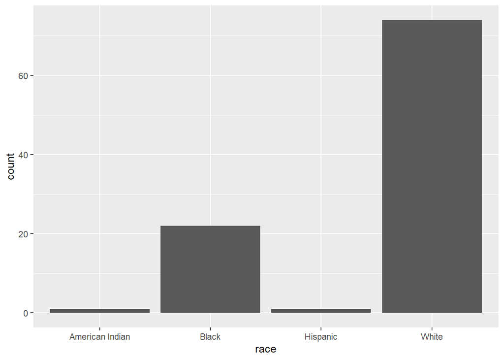

```r
ggplot(data = Marriage, mapping = aes(x=race)) +  # Specify the data and x-axis
  geom_bar()                                      # Plot the bar chart
```

Just by looking at the data, we can see that most of the marriage participants are white, followed by black. We also have a few marriages amongs American Indian and Hispanic.

You can check the documentation for `geom_bar()` by running `?geom_bar` or `help(geom_bar)`. You can for example, change the color for the bars.

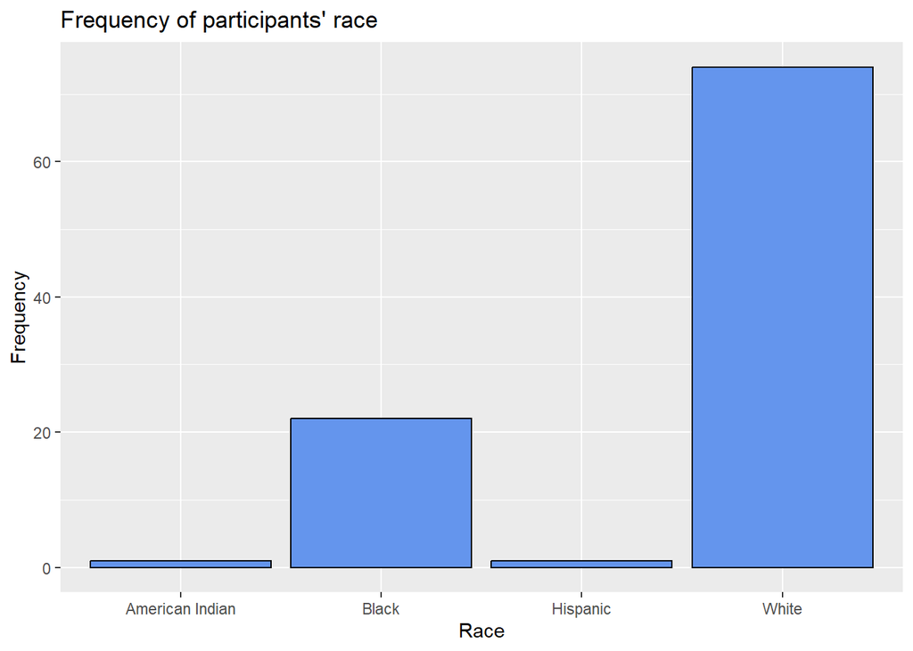

```r
# Specify the data and x-axis
ggplot(data = Marriage, mapping = aes(x=race)) +

  # Plot the bar chart with blue rectangle an black border
  geom_bar(fill = "cornflowerblue",
           color="black") +

  # Change the x and y labels, and the title
  labs(x = "Race", y="Frequency", title="Frequency of participants' race")
```

### Relative frequency as the y-axis

By default, `geom_bar()` uses the frequency for the y-axis and maps it to `count`. The `aes(x=race)` is actually a short for `aes(x=race, y=after_stat(count))` using default value for `y`. We can modify the `y` argument in `aes()` to calculate the proportion by setting `y=after_stat(count/sum(count))`. We can also change the y-axis to percentages using the `label_percent()` function in `scales` package as the `labels` argument in `scale_y_continuous()`.

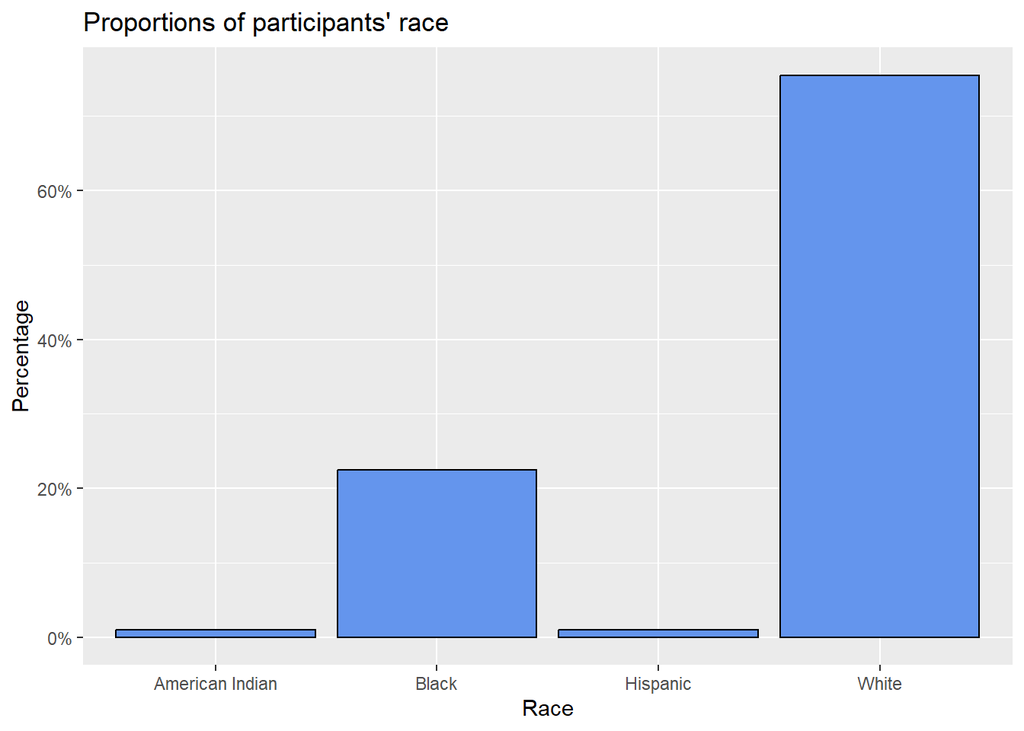

```r
# Specify the data, x-axis, and calculate the y axis
ggplot(data = Marriage, mapping = aes(x=race, y=after_stat(count/sum(count)))) +

  # Plot the bar chart
  geom_bar(fill = "cornflowerblue",
           color="black") +

  # Change the y scale to be percentage
  scale_y_continuous(labels=scales::label_percent()) +

  # Change the x and y labels, and the title
  labs(x = "Race", y="Percentage", title="Proportions of participants' race")
```

Alternatively, we can create a table that shows the percent of each group using the `count()` and `mutate()` functions, and proceed to use `geom_col()` to plot the bar chart with the percentage being the y-axis.

```r
newdata <- Marriage %>%
  count(race) %>%
  mutate(rel.freq = n/sum(n))
newdata
```

```
##              race  n   rel.freq
## 1 American Indian  1 0.01020408
## 2           Black 22 0.22448980
## 3        Hispanic  1 0.01020408
## 4           White 74 0.75510204
```

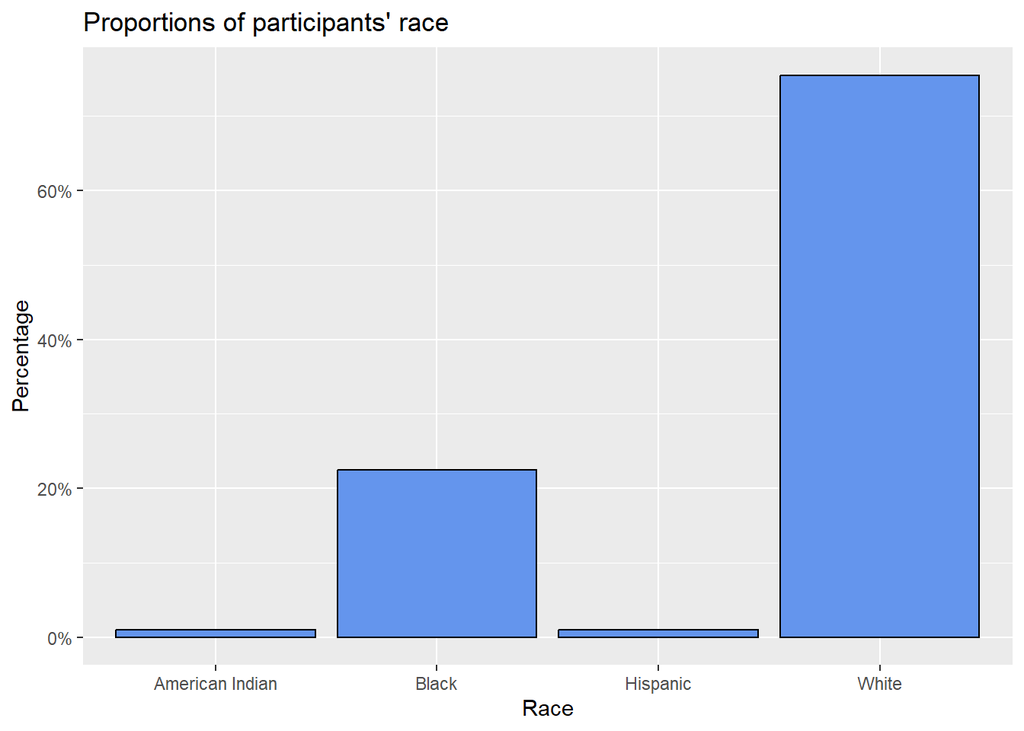

```r
# Specify the data, x-axis, y-axis
ggplot(data = newdata, mapping = aes(x=race, y=rel.freq)) +

  # Plot the bar chart using geom_col to use y-value directly
  geom_col(fill = "cornflowerblue",
           color="black") +

  # Change the y scale to be percentage
  scale_y_continuous(labels=scales::label_percent()) +

  # Change the x and y labels, and the title
  labs(x = "Race", y="Percentage", title="Proportions of participants' race")
```

Note that the code above uses `geom_col()` as it uses the `y` mapping directly. If we want to use `geom_bar()`, we have to add the argument `stat=identity` so that the function does not try to ‘count’ observations.

```r
ggplot(data = newdata, mapping = aes(x=race, y=rel.freq)) +

  # Plot the bar chart using geom_bar but use stat=identity to use y-value directly
  geom_bar(stat="identity",
           fill = "cornflowerblue",
           color="black") +
  scale_y_continuous(labels=scales::label_percent()) +

  labs(x = "Race", y="Percentage", title="Proportions of participants' race")
```

### Horizontal bar chart

The horizontal bar chart is sometimes preferred especially if we a lot of categories and we do not want the category names to overlap each other in the vertical bar chart. To create a horizontal bar chart, simply specify `y` to be the categorical variable in the `aes()` mapping. Note that the `x` and `y` in the label have to be changed respectively.

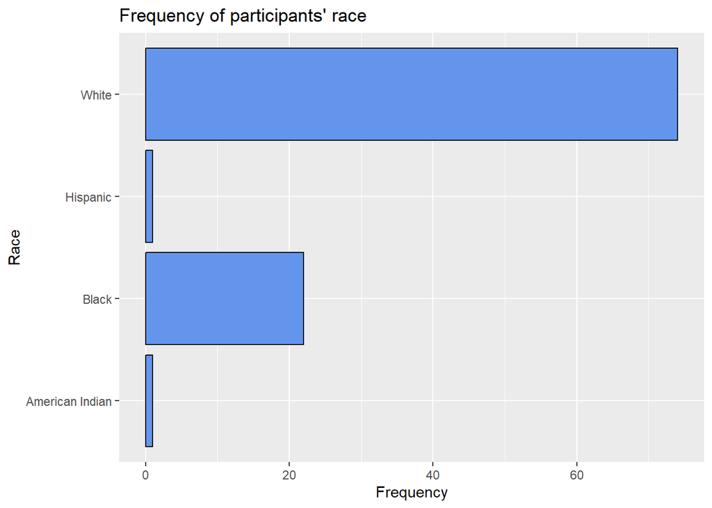

```r
ggplot(data = Marriage, mapping = aes(y=race)) +

  # Plot bar chart
  geom_bar(fill = "cornflowerblue",
           color="black") +

  labs(y = "Race", x="Frequency", title="Frequency of participants' race")
```

Alternatively, we can also use `coord_flip()` function to flip the x and y-axes to produce a horizontal bar chart.

```r
ggplot(data = Marriage, mapping = aes(x=race)) +

  # Plot bar chart
  geom_bar(fill = "cornflowerblue",
           color="black") +
  labs(x = "Race", y="Frequency", title="Frequency of participants' race") +

  # Flip x and y axes
  coord_flip()
```

### Sorting categories

Notice that by default, `geom_bar()` sorts the categories alphabetically. If we want to sort it by the frequency or the y-axis, we may want to use `count()` function in the `dplyr` package to create a new data frame with the categories and their frequencies.

```r
newdata <- count(Marriage, race)
newdata
```

```
##              race  n
## 1 American Indian  1
## 2           Black 22
## 3        Hispanic  1
## 4           White 74
```

Then, we can use `reorder()` function in base R to reorder the categories by the frequency (or in this case `n`). By default, it sorts in increasing order, but we can use `decreasing=TRUE` in the argument to make it in decreasing order. Then, we can use `geom_col()` to use the `y` values directly.

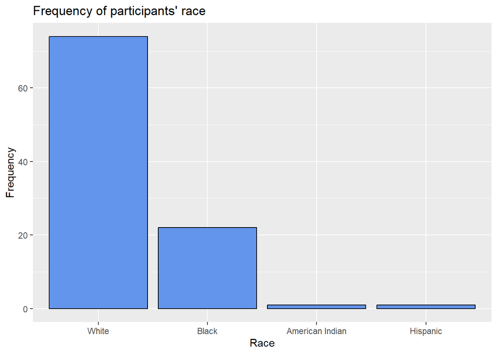

```r
# Specify the data, x-axis, y-axis
# For x-axis, reorder the race in decreasing order of n
ggplot(data = newdata, mapping = aes(x=reorder(race, n, decreasing=TRUE),
                                     y=n)) +

  # Plot the bar chart using y values directly
  geom_col(fill = "cornflowerblue",
           color="black") +

  # Change the x and y labels, and the title
  labs(x = "Race", y="Frequency", title="Frequency of participants' race")
```

Alternatively, if we have a specific order in mind, we can use `factor()` in the `x` argument in the `aes()` mapping. This does not require us to create another data frame as in the previous example. To use `factor()` in the argument, you just have to specify the variable and the order using `levels`. Note that the x-axis label have to be specified using `labs()` if `factor()` is used in `x`. Otherwise, the x-axis becomes “factor(…)”.

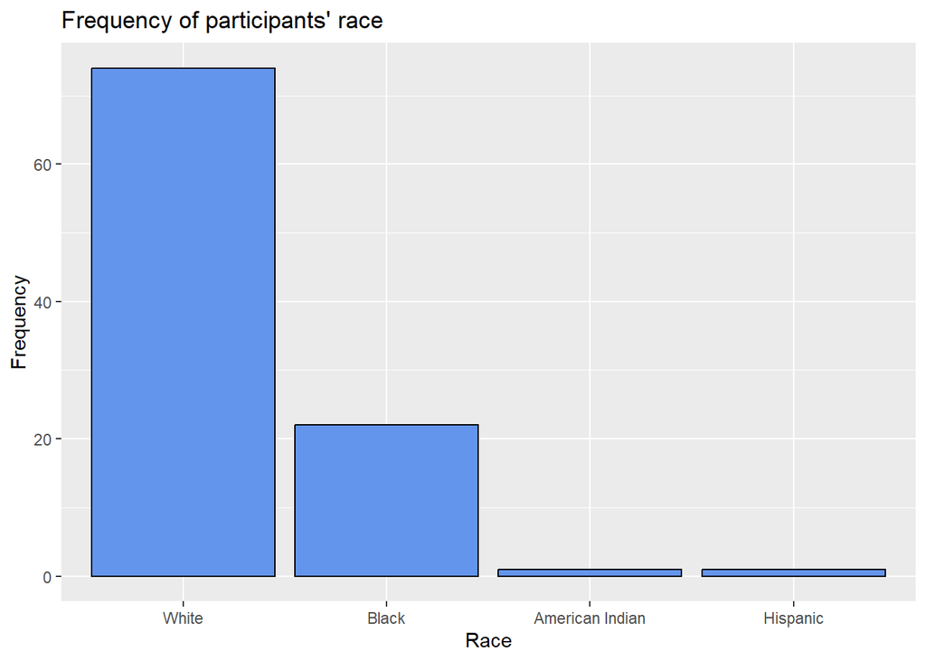

```r
# Specify the data, x-axis, y-axis
# For x-axis change the levels according to desired order
ggplot(data = Marriage,
       mapping = aes(x = factor(race,
                                levels = c("White", "Black",
                                           "American Indian", "Hispanic")))) +

  # Plot bar chart
  geom_bar(fill = "cornflowerblue",
           color="black") +
  labs(x = "Race", y="Frequency", title="Frequency of participants' race")
```

### Labeling bars

The values of the bar chart can be shown on top of each bar using the `geom_text()` function. In the code below, we add the `geom_text()` function in the chain, use `n` (or frequency) as the text or label, and move the vertical position of the text a little bit above `n` level by specifying `vjust=-0.5`.

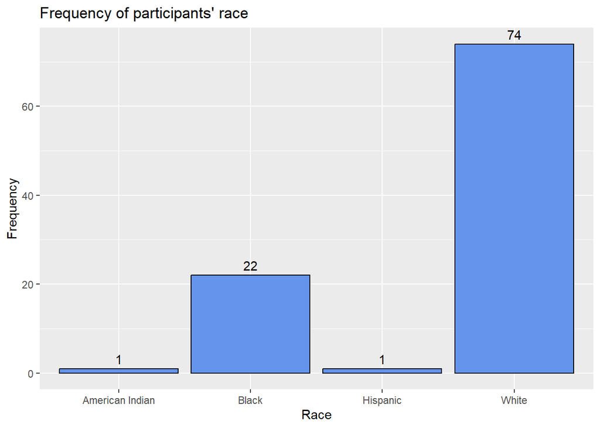

```r
# Specify the data, x-axis, y-axis
ggplot(data = newdata, mapping = aes(x=race, y=n)) +

  # Plot the bar chart, do not use calculate count for y-axis
  geom_bar(stat="identity",
           fill = "cornflowerblue",
           color="black") +

  # Add text at 0.5 above the bar showing n
  geom_text(mapping = aes(label = n), vjust=-0.5) +

  # Change the x and y labels, and the title
  labs(x = "Race", y="Frequency", title="Frequency of participants' race")
```

If we want to show labels in percentage, we can calculate the percentage manually, and use `round()` function to round the percentage to maybe two decimal places. Then, we can use `paste0` function to combine the calculated percentage and the “%” sign in a string, and use it as the label in `aes()` function in `geom_text()`.

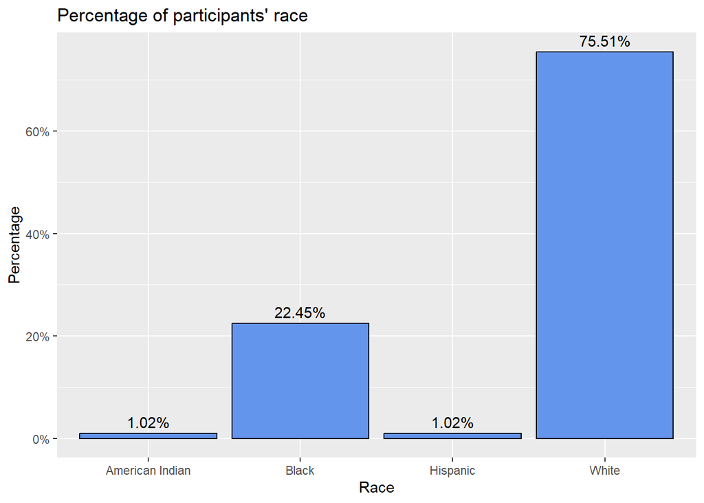

```r
# Specify the data, x-axis, y-axis, calculate the y-axis to be proportion
ggplot(data = newdata, mapping = aes(x=race, y=n/sum(n))) +

  # Plot the bar chart, do not use calculate count for y-axis
  geom_bar(stat="identity",
           fill = "cornflowerblue",
           color="black") +

  # Add text at 0.5 above the bar showing percentange
  geom_text(mapping = aes(label = paste0(round(n/sum(n)*100,2),"%")), vjust=-0.5) +

  # Change the y scale to be percentage
  scale_y_continuous(labels = scales::label_percent()) +

  # Change the x and y labels, and the title
  labs(x = "Race", y="Percentage", title="Percentage of participants' race")
```

## Pie Chart

Pie chart can be used when we want to visualize proportions in the data. Pie chart divides a circle into several slices, and each slice represent a category. The angle of a slice represents the fraction of the total the category represents.

Unfortunately, there is no specific geom function for pie chart in `ggplot2` package. However, there is a trick that can be used to produce it, by using `geom_bar()` to make it into a stacked bar chart, and `coord_polar()` to make it circular.

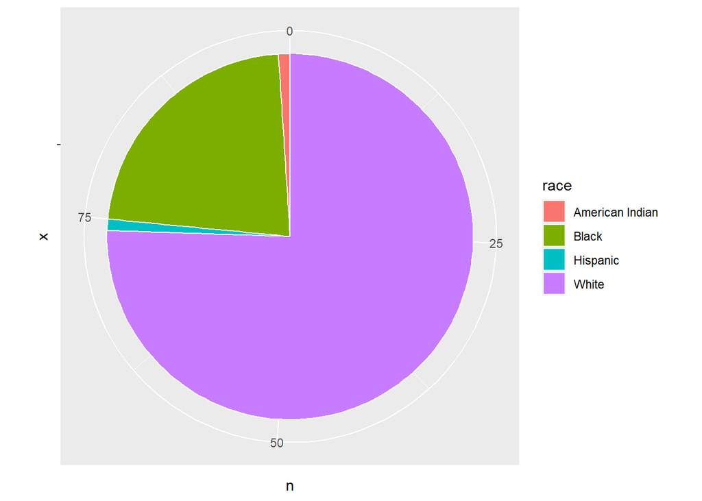

```r
ggplot(data = newdata, mapping = aes(x="", y=n, fill=race))+
  geom_bar(stat="identity", width=1, color="white") +
  coord_polar(theta = "y", start=0)
```

To improve pie chart, we can use `theme_void()` to remove the grid, background and axes. Then, we add labels using `geom_text()`.

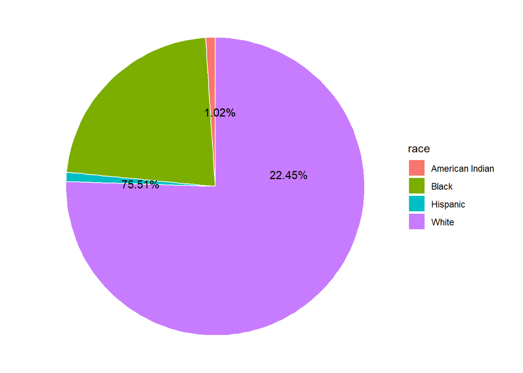

```r
ggplot(data=newdata, aes(x="", y=n, fill=race))+
  geom_bar(stat="identity", width=1, color="white") +
  coord_polar(theta = "y", start=0) +
  theme_void() +
  geom_text(aes(y = n, label = paste0(round(n/sum(n)*100,2),"%")))
```

You can read more info on this https://r-graph-gallery.com/piechart-ggplot2.html.

Many analysts reject and detest pie chart, and prefer to use a bar chart instead to show data. This is partly because humans are easier to read length than angle in visuals. However, the popularity of pie chart cannot be denied. If you plan to use a pie chart, we suggest you include labels showing either the value or percentage for each slice.

## Treemap

Treemap is another way that can be used to visualize the distribution of proportion. In treemaps, a rectangle is drawn to represent the total value. Then the rectangle is divided into several smaller rectangles and the area of a section represents a category’s fraction of the total.

Unfortunately, just like pie chart, there is no geom function for it in ggplot2 package. However, unlike the pie chart, there is a function called `geom_treemap()` that you can use from `treemapify` package.

```r
install.packages("treemapify")
library(treemapify)
```

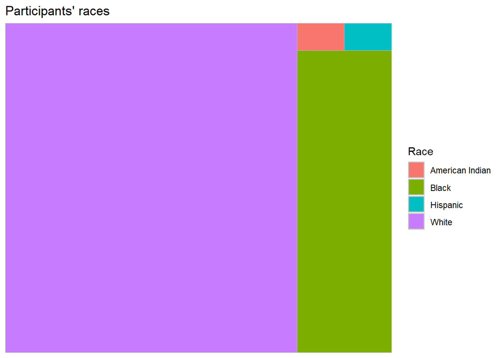

```r
newdata <- count(Marriage, race)

ggplot(data=newdata, mapping = aes(fill=race, area=n)) +
  geom_treemap() +
  labs(title='Participants\' races', fill="Race")
```

The `treemapify` package also include a function to add labels to the rectangles called `geom_treemap_text()`.

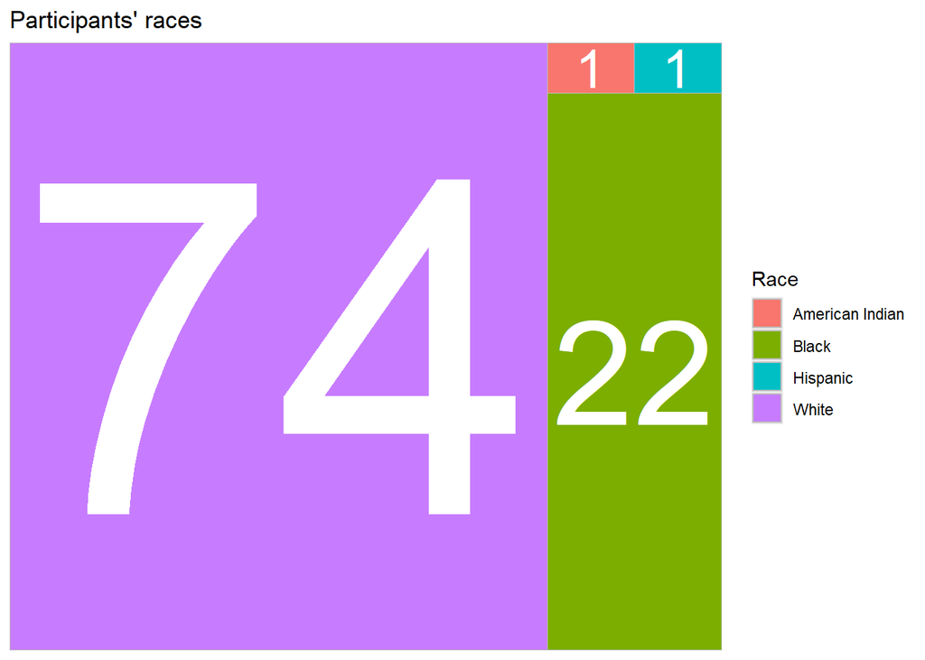

```r
ggplot(data=newdata, mapping = aes(fill=race, area=n)) +
  geom_treemap() +
  geom_treemap_text(mapping = aes(label=n),
                    color = "white", place="centre", grow=TRUE) +
  labs(title='Participants\' races', fill="Race")
```

Alternatively, you can remove the legend and include the category name in the label.

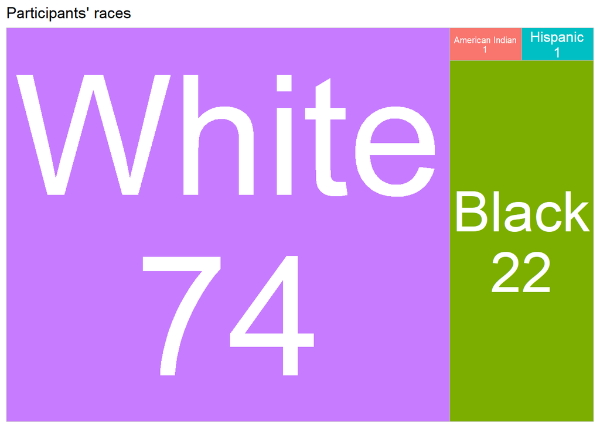

```r
ggplot(data=newdata, mapping = aes(fill=race, area=n)) +
  geom_treemap() +
  geom_treemap_text(mapping = aes(label=paste0(race,"\n", n)),
                    color = "white", place="centre", grow=TRUE) +
  labs(title='Participants\' races') +
  theme(legend.position = "n")
```

Just like pie chart, treemaps are not suggested to be used without labels showing a sections value or percentage. This is due to difficulty for human to read area as compared to length in a visual.

## Waffle Chart

Waffle chart is another useful visual tool to display proportions of data. In waffle chart, a grid of rectangles is used to represent the whole data. Then, each square or grid cell is colored to represent a category.

To use waffle chart in ggplot2, the `waffle` package must be installed and use.

```r
install.packages("waffle")
library(waffle)
```

Then, we can use `geom_waffle()` function in the package to draw the waffle chart.

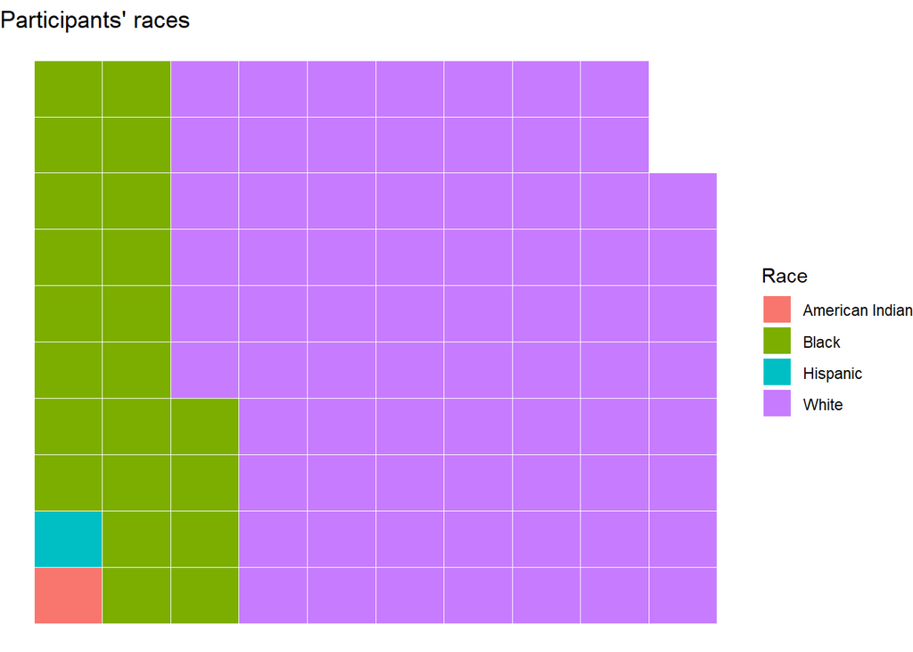

```r
# Create new data for the count of categories and arrange the
# row in ascending order according to n or frequency
newdata <- Marriage %>%
  count(race) %>%
  arrange(n)

# Plot the waffle chart
ggplot(data=newdata, mapping = aes(fill=race, values=n)) +
  geom_waffle(color="white") +
  theme_void() +
  labs(title='Participants\' races', fill="Race")
```

## Text Data

For text data, we can first process the corpus of text by breaking the text into root words and remove stop words or commonly occurring words such as “is”, “are”, “the”, “a”, “and”, and so on. The, we can count the frequency of root words to study its distribution.

We can visualise the frequency of words using bar chart. However, one popular choice to display commonly used words in text data is the word cloud. In word cloud, the top used words identified and placed in a cloud-like visual where the size of a word represent its frequency.

There is no word cloud in the ggplot2 package. However, as before, we can use the `ggwordcloud` package and its `geom_text_wordcloud()` to produce word cloud.

```r
install.packages("ggwordcloud")
library(ggwordcloud)
```

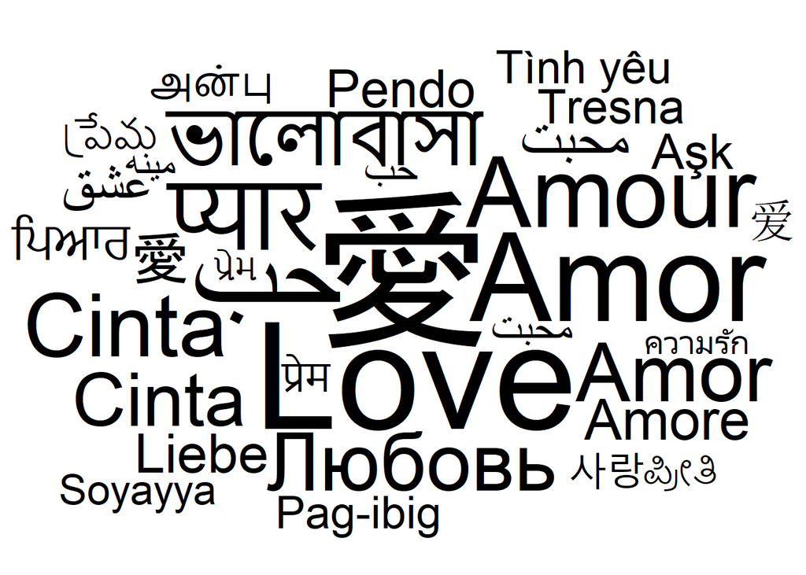

```r
ggplot(data = love_words_small, mapping = aes(label=word, size=speakers)) +
  geom_text_wordcloud() +
  scale_size_area(max_size = 40) +
  theme_minimal()
```

Alternatively, you can use the `rquery.wordcloud()` function that you can download from STHDA website by using the `source()` function. You can read more on the function on https://www.sthda.com/english/wiki/word-cloud-generator-in-r-one-killer-function-to-do-everything-you-need.

To use the script, several packages have to be installed and loaded first.

```r
install.packages(c("tm", "SnowballC",
                   "wordcloud", "RColorBrewer",
                   "RCurl", "XML"))
```

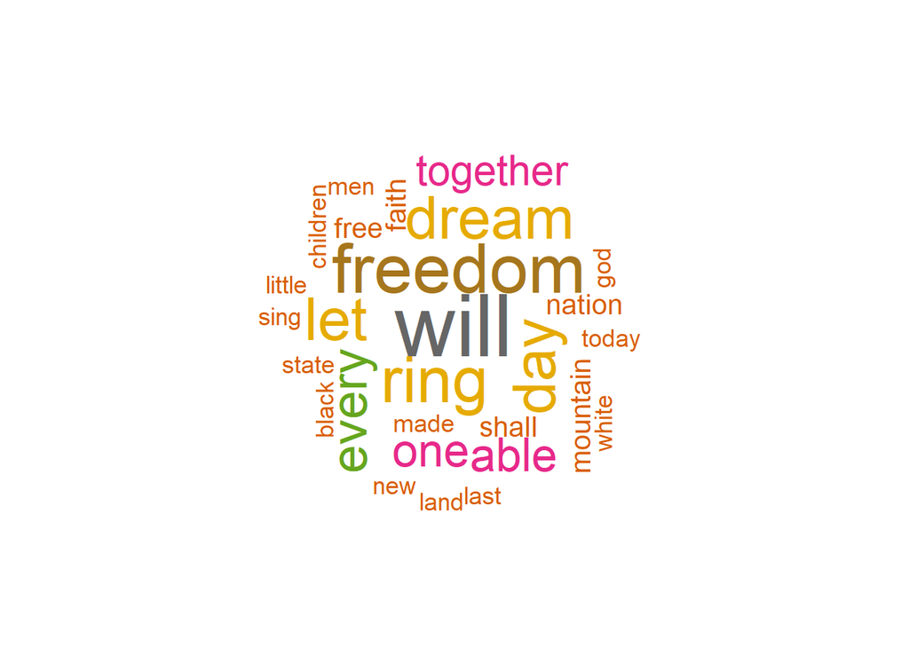

```r
# Specify the script location
script <- "http://www.sthda.com/upload/rquery_wordcloud.r"

# Run the script
source(script)

# Specify the path of a text tile
filePath <-
  "https://www.sthda.com/sthda/RDoc/example-files/martin-luther-king-i-have-a-dream-speech.txt"

# Plot the word cloud
res<-rquery.wordcloud(filePath,
                      type ="file",
                      lang = "english",
                      textStemming=FALSE,
                      min.freq=3,
                      max.words=200)
```

## Conclusion

In this topic, we have discussed some of the visuals, plots, and charts we can use to display the distribution of categorical data. Some of them are used extensively, especially the bar chart. In the next topic, we will talk about visuals to display distributions of quantitative data.